# Analysis of European Soccer Database

We continue with these same steps and analysis for the remaining leagues.

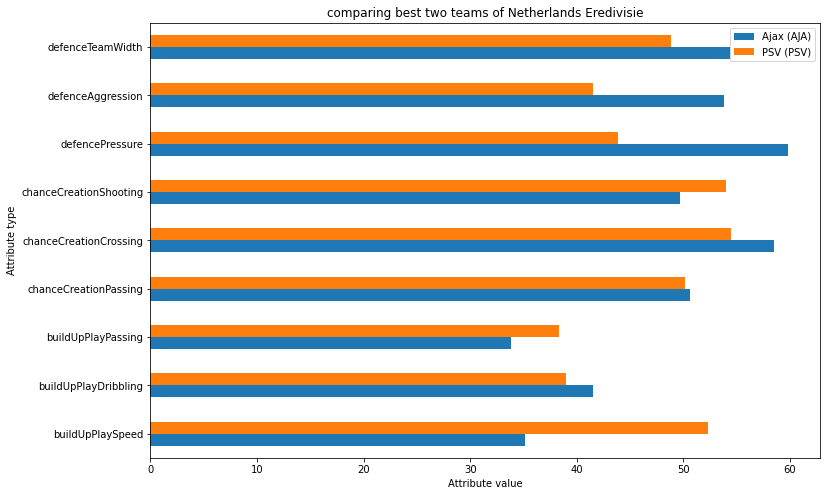

```python
# Netherlands Eredivisie	Ajax (AJA)	PSV (PSV)
# Netherlands Eredivisie
compare_attr = pd.DataFrame(data=team_attribute.query('team_name == "Ajax (AJA)"').mean(),
                            columns=['Ajax (AJA)'])
compare_attr['PSV (PSV)'] = team_attribute.query('team_name == "PSV (PSV)"').mean()
compare_attr = compare_attr[3:]
compare_attr

compare_attr.plot.barh(width=0.50, figsize=(12,8))
plt.title('comparing best two teams of Netherlands Eredivisie')
plt.ylabel('Attribute type')
plt.xlabel('Attribute value')
plt.legend(loc = 0);
```

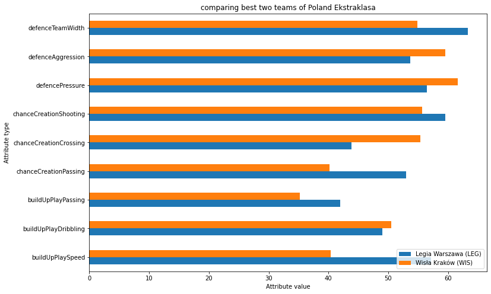

```python
# Poland Ekstraklasa	Legia Warszawa (LEG)	Wisła Kraków (WIS)
# Poland Ekstraklasa
compare_attr = pd.DataFrame(data=team_attribute.query('team_name == "Legia Warszawa (LEG)"').mean(),
                            columns=['Legia Warszawa (LEG)'])
compare_attr['Wisła Kraków (WIS)'] = team_attribute.query('team_name == "Wisła Kraków (WIS)"').mean()
compare_attr = compare_attr[3:]
compare_attr

compare_attr.plot.barh(width=0.50, figsize=(12,8))
plt.title('comparing best two teams of Poland Ekstraklasa')
plt.ylabel('Attribute type')
plt.xlabel('Attribute value')
plt.legend(loc = 0);
```

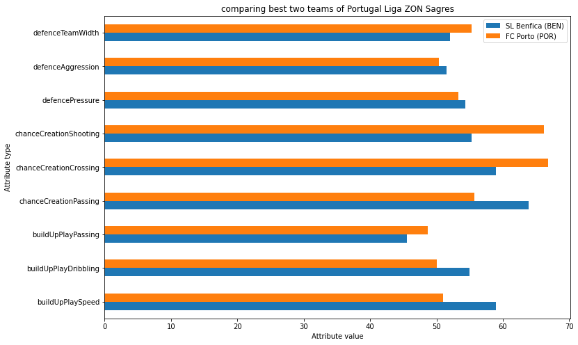

```python
# Portugal Liga ZON Sagres	SL Benfica (BEN)	FC Porto (POR)
# Portugal Liga ZON Sagres
compare_attr = pd.DataFrame(data=team_attribute.query('team_name == "SL Benfica (BEN)"').mean(),
                            columns=['SL Benfica (BEN)'])
compare_attr['FC Porto (POR)'] = team_attribute.query('team_name == "FC Porto (POR)"').mean()
compare_attr = compare_attr[3:]
compare_attr

compare_attr.plot.barh(width=0.50, figsize=(12,8))
plt.title('comparing best two teams of Portugal Liga ZON Sagres')
plt.ylabel('Attribute type')
plt.xlabel('Attribute value')
plt.legend(loc = 0);
```

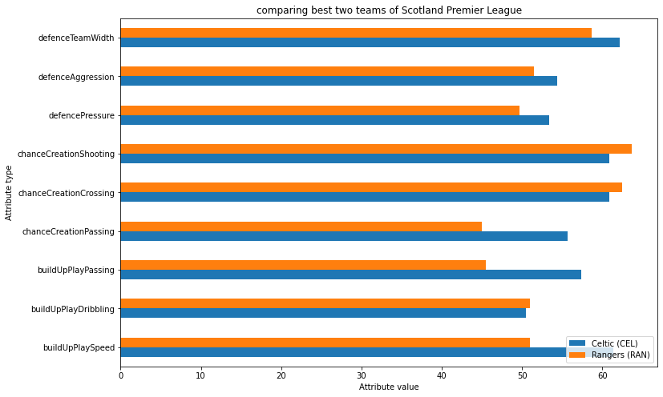

```python
# Scotland Premier League	Celtic (CEL)	Rangers (RAN)
# Scotland Premier League
compare_attr = pd.DataFrame(data=team_attribute.query('team_name == "Celtic (CEL)"').mean(),
                            columns=['Celtic (CEL)'])
compare_attr['Rangers (RAN)'] = team_attribute.query('team_name == "Rangers (RAN)"').mean()
compare_attr = compare_attr[3:]
compare_attr

compare_attr.plot.barh(width=0.50, figsize=(12,8))
plt.title('comparing best two teams of Scotland Premier League')
plt.ylabel('Attribute type')
plt.xlabel('Attribute value')
plt.legend(loc = 0);
```

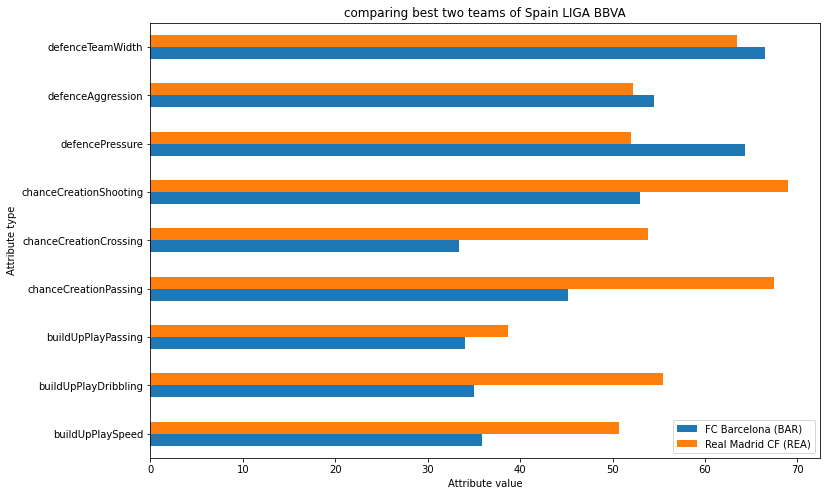

```python
# Spain LIGA BBVA	FC Barcelona (BAR)	Real Madrid CF (REA)
# Spain LIGA BBVA
compare_attr = pd.DataFrame(data=team_attribute.query('team_name == "FC Barcelona (BAR)"').mean(),
                            columns=['FC Barcelona (BAR)'])
compare_attr['Real Madrid CF (REA)'] = team_attribute.query('team_name == "Real Madrid CF (REA)"').mean()
compare_attr = compare_attr[3:]
compare_attr

compare_attr.plot.barh(width=0.50, figsize=(12,8))
plt.title('comparing best two teams of Spain LIGA BBVA')
plt.ylabel('Attribute type')
plt.xlabel('Attribute value')
plt.legend(loc = 0);
```

Interestingly in LIGA BBVA league, even though the second team(Real Madrid) was ahead 6 attributes in total 9, the first most winner was FC Barcelona.

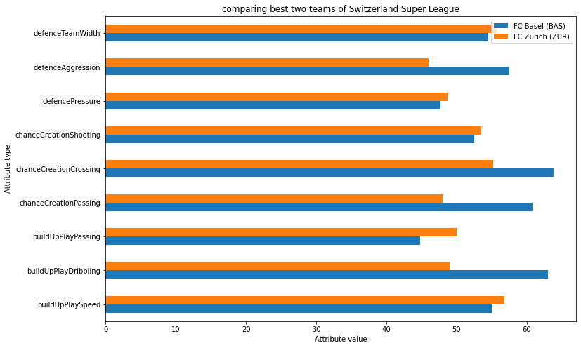

```python
# Switzerland Super League	FC Basel (BAS)	FC Zürich (ZUR)
# Switzerland Super League
compare_attr = pd.DataFrame(data=team_attribute.query('team_name == "FC Basel (BAS)"').mean(),
                            columns=['FC Basel (BAS)'])
compare_attr['FC Zürich (ZUR)'] = team_attribute.query('team_name == "FC Zürich (ZUR)"').mean()
compare_attr = compare_attr[3:]
compare_attr

compare_attr.plot.barh(width=0.50, figsize=(12,8))
plt.title('comparing best two teams of Switzerland Super League')
plt.ylabel('Attribute type')
plt.xlabel('Attribute value')
plt.legend(loc = 0);
```

### 4. Are teams scoring more goal when playing home or away? How about the number of wins when home or away?

For this quesetion, we wanted to anaylsis if the old superstition of the "home field advantage" was true by comparing the wins of teams as home teams vs their away wins.

```python
team_goal_won_total['game_count_as_hometeam'] = 'NAN'
team_goal_won_total['goal_count_as_hometeam'] = 'NAN'
team_goal_won_total['win_count_as_hometeam'] = 'NAN'

team_goal_won_total['game_count_as_awayteam'] = 'NAN'
team_goal_won_total['goal_count_as_awayteam'] = 'NAN'
team_goal_won_total['win_count_as_awayteam'] = 'NAN'

team_goal_won_total['num_total_game'] = 'NAN'
```

```python
team_match['season'] = team_match['season_start'] + " - " + team_match['season_end']
```

```python
for index, row in team_goal_won_total.iterrows():
    season = team_goal_won_total.iloc[index, 1]
    team_name = team_goal_won_total.iloc[index, 2]
    df = team_match[(team_match['season'] == season) & (team_match['home_team'] == team_name)]
    team_goal_won_total.iloc[index, 6] = df['home_team_goal'].sum()
    team_goal_won_total.iloc[index, 5] = df.shape[0]
    new_df = df[df['winner'] == team_name]
    team_goal_won_total.iloc[index, 7] = new_df.shape[0]

    df = team_match[(team_match['season'] == season) & (team_match['away_team'] == team_name)]
    team_goal_won_total.iloc[index, 9] = df['away_team_goal'].sum()
    team_goal_won_total.iloc[index, 8] = df.shape[0]
    new_df = df[df['winner'] == team_name]
    team_goal_won_total.iloc[index, 10] = new_df.shape[0]
    team_goal_won_total.iloc[index, 11] = team_goal_won_total.iloc[index, 5] + team_goal_won_total.iloc[index, 8]
```

```python
team_goal_won_total = team_goal_won_total[['leagueName', 'season', 'team_name', 'num_total_game', 'game_count_as_hometeam',
                                           'game_count_as_awayteam', 'count_wins', 'win_count_as_hometeam',
                         'win_count_as_awayteam', 'total_num_goal', 'goal_count_as_hometeam', 'goal_count_as_awayteam']]
team_goal_won_total = team_goal_won_total.rename(columns={"num_total_game": "game_count_total", "count_wins": "win_count_total", "total_num_goal": "goal_count_total"})
team_goal_won_total.head()
```

|  | leagueName | season | team_name | game_count_total | game_count_as_hometeam | game_count_as_awayteam | win_count_total | win_count_as_hometeam | win_count_as_awayteam | goal_count_total | goal_count_as_hometeam | goal_count_as_awayteam |
| --- | --- | --- | --- | --- | --- | --- | --- | --- | --- | --- | --- | --- |
| 0 | Belgium Jupiler League | 2008 - 2009 | Beerschot AC (BAC) | 34 | 17 | 17 | 11 | 9 | 2 | 44 | 32 | 12 |
| 1 | Belgium Jupiler League | 2008 - 2009 | Club Brugge KV (CLB) | 34 | 17 | 17 | 18 | 11 | 7 | 59 | 37 | 22 |
| 2 | Belgium Jupiler League | 2008 - 2009 | FCV Dender EH (DEN) | 34 | 17 | 17 | 9 | 5 | 4 | 44 | 21 | 23 |
| 3 | Belgium Jupiler League | 2008 - 2009 | KAA Gent (GEN) | 34 | 17 | 17 | 17 | 9 | 8 | 67 | 31 | 36 |
| 4 | Belgium Jupiler League | 2008 - 2009 | KRC Genk (GEN) | 34 | 17 | 17 | 15 | 7 | 8 | 48 | 23 | 25 |

With the table created, we can now visualize the results to make it easier to interpret.

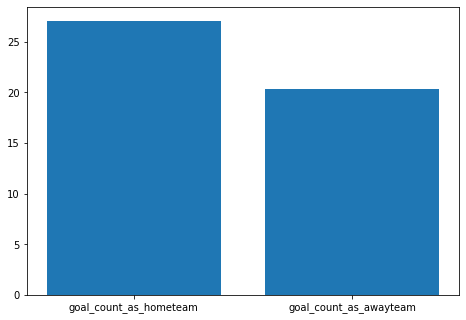

```python
new_df = team_goal_won_total[team_goal_won_total.columns[-2:]]
df1 = new_df.mean().to_frame()
df1.reset_index(inplace=True)
df1 = df1.rename(columns={"index": "type", 0: "mean_goal_count"})

fig = plt.figure()
ax = fig.add_axes([0,0,1,1])
x = df1.type
y = df1.mean_goal_count
ax.bar(x,y)
plt.show()
```

We come up with the mean value of total goals as a home team is higher than the mean value of total goals as an away team.

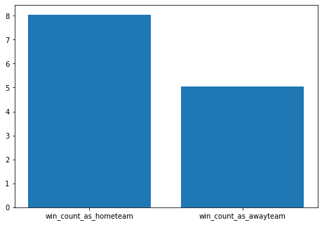

```python
# win vs home or away
new_df = team_goal_won_total[team_goal_won_total.columns[7:9]]
df1 = new_df.mean().to_frame()
df1.reset_index(inplace=True)
df1 = df1.rename(columns={"index": "type", 0: "mean_win_count"})

fig = plt.figure()
ax = fig.add_axes([0,0,1,1])
x = df1.type
y = df1.mean_win_count
ax.bar(x,y)
plt.show()
```

Likewise, the mean value of home team victories is much higher than when away.

### 5. Is there a relationship between player attributes and their overall rating?

For this section, we wanted to start a surface level exploration into the relationship between the individual player's overall rating and their attributes. We accomplish this by creating a linear regression with a subset of the player's attributes and their associated rating to see if there were any trends shown by plotting the results.

```
[-0.02712711  0.01414654  0.10463825  0.08053166  0.13160613  0.07051224
  0.00833057 -0.01379527 -0.01003446]
```

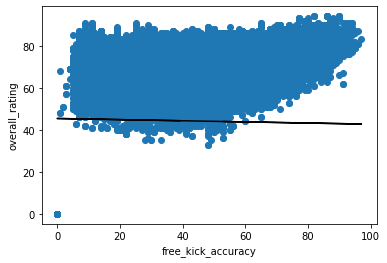

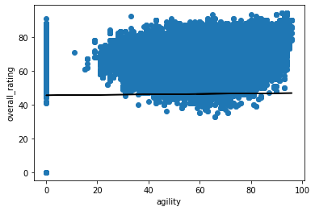

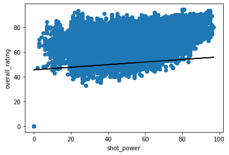

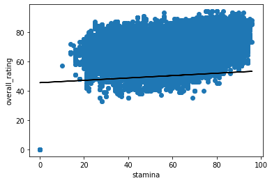

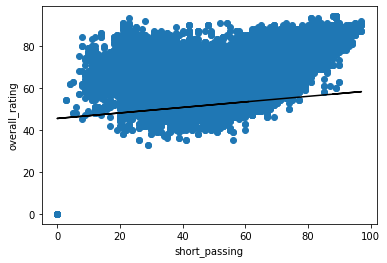

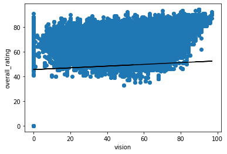

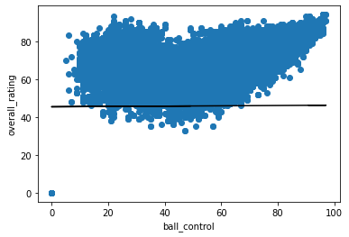

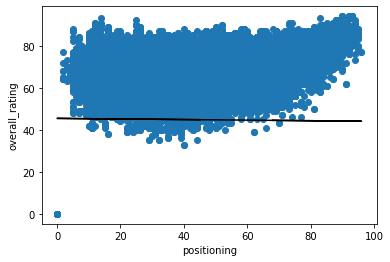

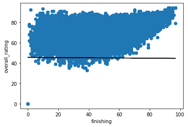

```python
attributes = player_Attributes[['free_kick_accuracy','agility','shot_power','stamina', 'short_passing', 'vision', 'ball_control', 'positioning', 'finishing']].fillna(0).astype('int32')

reg = LinearRegression().fit(attributes, player_Attributes['overall_rating'].fillna(0))

print(reg.coef_)

i = 0
for x in list(attributes):
    fig, ax = plt.subplots()
    ax.set_ylabel('overall_rating')
    ax.set_xlabel(x)
    ax.scatter(attributes[x],player_Attributes['overall_rating'].fillna(0))
    ax.plot(attributes[x], reg.coef_[i]*attributes[x] + reg.intercept_, 'k')
    i = i + 1
plt.show()
```

From the results, we can see that there is a relationship present and that could inducate that some attributes weight towards a higher rating more than others. We will continue this exploration when we get to building our models.

### 6. Which players have the highest overall rating per year?

Here we wanted to see who was at the top of the game for each year in the dataset.

```python
grouped_player = player_Attributes.groupby([player_Attributes['date'].dt.year])
players_list = []
ratings = []
seasons = []
for name, group in grouped_player:
    df = group.sort_values('overall_rating', ascending=False)
    row = df.iloc[0]
    player = players.loc[players[players['player_fifa_api_id'] == row['player_fifa_api_id']].index, 'player_name']
    players_list.append(player.values[0])
    ratings.append(row['overall_rating'])
    seasons.append(name)

overall_rating = pd.DataFrame(data={"seasons" : seasons, 'player' : players_list, "rating" : ratings})
overall_rating
```

|  | seasons | player | rating |
| --- | --- | --- | --- |
| 0 | 2007 | Wayne Rooney | 93.0 |
| 1 | 2008 | Cristiano Ronaldo | 91.0 |
| 2 | 2009 | Iker Casillas | 91.0 |
| 3 | 2010 | Lionel Messi | 90.0 |
| 4 | 2011 | Lionel Messi | 94.0 |
| 5 | 2012 | Lionel Messi | 94.0 |
| 6 | 2013 | Lionel Messi | 94.0 |
| 7 | 2014 | Lionel Messi | 94.0 |
| 8 | 2015 | Lionel Messi | 94.0 |
| 9 | 2016 | Neymar | 90.0 |

Correlations from these results:

Wayne Rooney and cristiano Ronaldo were the two highest rated players during in 2007/2008, both of which played on Manchester United. Manchester United was also the team with the most wins in the Premier League during those years. Similarly, Messi and Neymar have been apart of Barcelona the years they were the highest rated players and while concurrently there at Barcelona, the club had the most wins in the spanish league.

Incidentally, it seems like the highest rated player comes from the spanish league for 8 years in a row here.

### 7. What precent of player prefer their left foot? right foot? or both? Does this connect with their rating at all?

For this question, we were curious to see the distributions of the players preferred foot. As well, in some sports using a different hand or foot than the major sometimes results in small advantages (take left handers in tennis for example), does this apply to this sport as well?

```python
p_A_1= player_Attributes[['player_api_id', 'preferred_foot', 'overall_rating', 'potential']]
p_A_1.head()
```

|  | player_api_id | preferred_foot | overall_rating | potential |
| --- | --- | --- | --- | --- |
| 0 | 505942 | right | 67.0 | 71.0 |
| 1 | 505942 | right | 67.0 | 71.0 |
| 2 | 505942 | right | 62.0 | 66.0 |
| 3 | 505942 | right | 61.0 | 65.0 |
| 4 | 505942 | right | 61.0 | 65.0 |

```python
p_A_1= p_A_1.groupby(['player_api_id', 'preferred_foot']).mean()  # getting the average player rating
p_A_1.head()
```

| player_api_id | preferred_foot | overall_rating | potential |
| --- | --- | --- | --- |
| 2625 | right | 60.142857 | 61.142857 |
| 2752 | right | 69.380952 | 70.380952 |
| 2768 | left | 69.285714 | 70.571429 |
| 2770 | left | 71.571429 | 75.285714 |
|  | right | 70.750000 | 72.000000 |

```python
# get the total number of players that are right, left or both and there rating
left_foot=0; left_rating=0.0
right_foot=0; right_rating =0.0
both=0;       both_rating = 0.0
checked=[]
for key, value in p_A_1.iterrows():
    if key[0] in checked:
        both +=1
        both_rating += value[0]
    elif key[1] == 'right':
        right_foot +=1
        checked.append(key[0])
        right_rating += value[0]
    else:
        left_foot +=1
        checked.append(key[0])
        left_rating += value[0]
```

```python
total_players= left_foot + right_foot + both
average_left_rating= left_rating/ left_foot
average_right_rating = right_rating/ right_foot
both_rating = both_rating/ both
```

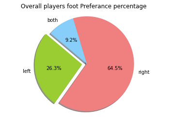

```python
# Data to plot
labels = 'left', 'right', 'both'
sizes = [left_foot, right_foot, both]
colors = ['yellowgreen', 'lightcoral', 'lightskyblue']
explode = (0.1, 0, 0)  # explode 1st slice

# Plot
plt.pie(sizes, explode=explode, labels=labels, colors=colors,
autopct='%1.1f%%', shadow=True, startangle=140)

plt.axis('equal')
plt.title("Overall players foot Preferance percentage ")
plt.show()
```

From this graph, we can see that the major of players in our dataset are prefer their right foot, while a smaller percentage prefer their left or both.

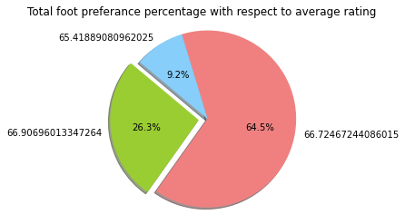

```python
# Data to plot
labels = average_left_rating, average_right_rating, both_rating
sizes = [left_foot, right_foot, both]
colors = ['yellowgreen', 'lightcoral', 'lightskyblue']
explode = (0.1, 0, 0)  # explode 1st slice

# Plot
plt.pie(sizes, explode=explode, labels=labels, colors=colors,
autopct='%1.1f%%', shadow=True, startangle=140)

plt.axis('equal')
plt.title("Total foot preferance percentage with respect to average rating ")
plt.show()
```

And from this graph, we can tell that their does not seem to be a bias in the ratings based off the player's prefer foot, possibly correlating to their also being no advantage for using the other foot or both.

### 8. What is the relationship between number of goals scored and the win percentage of the teams?

For this question, we wanted to see if their is a correlation between a high number of goals scored and a high win percentage.

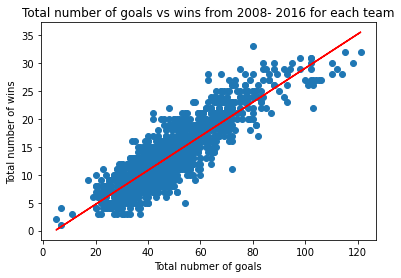

```python
plt.scatter(team_goal_won_total['goal_count_total'], team_goal_won_total['win_count_total'])
plt.ylabel("Total number of wins")
plt.xlabel("Total nubmer of goals")
plt.title("Total number of goals vs wins from 2008- 2016 for each team")

x= team_goal_won_total['goal_count_total'].values.reshape(-1,1)
y= team_goal_won_total['win_count_total']
reg_1 = LinearRegression()
reg_1 = reg_1.fit(x, y)

intercept= reg_1.intercept_
slope= reg_1.coef_
plt.plot(x, intercept + slope * x, 'red', label='reg')
plt.show()
```

```python
team_goal_won_total['winning_percentage']= (team_goal_won_total['win_count_total'] / team_goal_won_total['game_count_total'])*100
team_goal_won_total.head()
```

|  | leagueName | season | team_name | game_count_total | game_count_as_hometeam | game_count_as_awayteam | win_count_total | win_count_as_hometeam | win_count_as_awayteam | goal_count_total | goal_count_as_hometeam | goal_count_as_awayteam | winning_percentage |
| --- | --- | --- | --- | --- | --- | --- | --- | --- | --- | --- | --- | --- | --- |
| 0 | Belgium Jupiler League | 2008 - 2009 | Beerschot AC (BAC) | 34 | 17 | 17 | 11 | 9 | 2 | 44 | 32 | 12 | 32.3529 |
| 1 | Belgium Jupiler League | 2008 - 2009 | Club Brugge KV (CLB) | 34 | 17 | 17 | 18 | 11 | 7 | 59 | 37 | 22 | 52.9412 |
| 2 | Belgium Jupiler League | 2008 - 2009 | FCV Dender EH (DEN) | 34 | 17 | 17 | 9 | 5 | 4 | 44 | 21 | 23 | 26.4706 |
| 3 | Belgium Jupiler League | 2008 - 2009 | KAA Gent (GEN) | 34 | 17 | 17 | 17 | 9 | 8 | 67 | 31 | 36 | 50 |
| 4 | Belgium Jupiler League | 2008 - 2009 | KRC Genk (GEN) | 34 | 17 | 17 | 15 | 7 | 8 | 48 | 23 | 25 | 44.1176 |

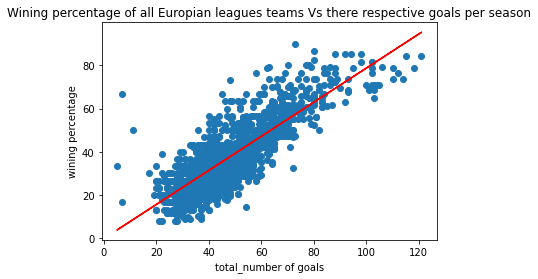

```python
plt.scatter(team_goal_won_total['goal_count_total'], team_goal_won_total['winning_percentage'])
plt.ylabel("wining percentage")
plt.xlabel("total_number of goals")
plt.title("Wining percentage of all Europian leagues teams Vs there respective goals per season")

x= team_goal_won_total['goal_count_total'].values.reshape(-1,1)
y=team_goal_won_total['winning_percentage']
reg_1 = LinearRegression()
reg_1 = reg_1.fit(x,y)

intercept= reg_1.intercept_
slope= reg_1.coef_
plt.plot(x, intercept + slope * x, 'red', label='reg')
plt.show()
```

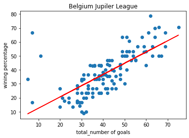

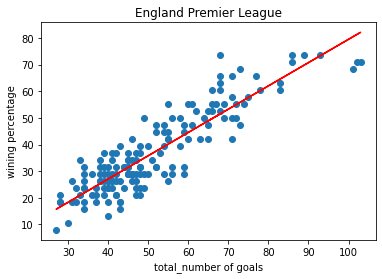

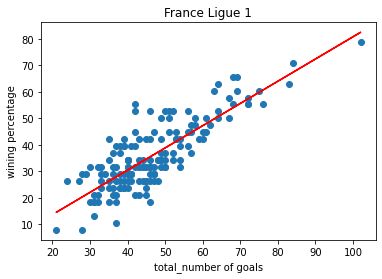

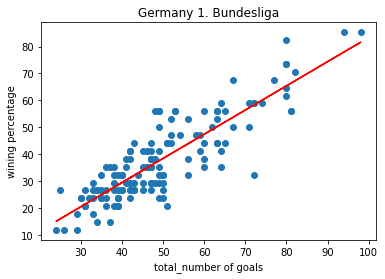

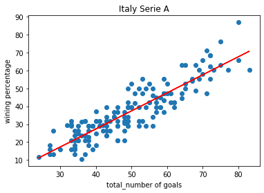

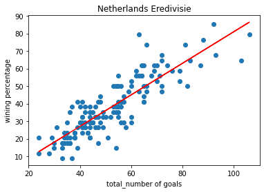

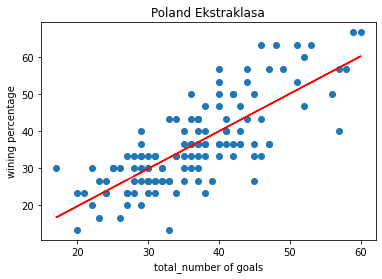

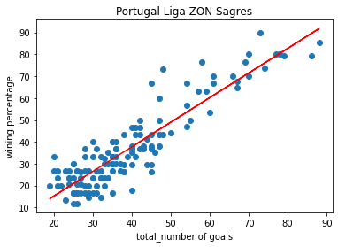

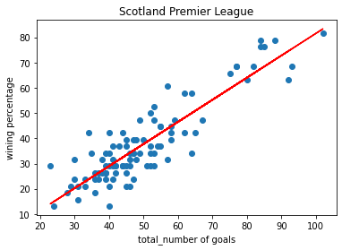

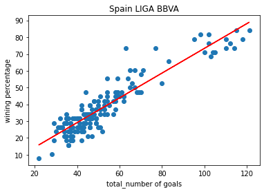

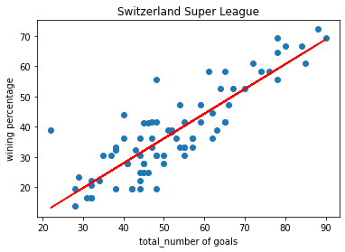

```python
a= team_goal_won_total.groupby(['leagueName'])

for index, value in a:

    x= value.goal_count_total
    y= value.winning_percentage

    plt.scatter(x, y)
    plt.ylabel("wining percentage")
    plt.xlabel("total_number of goals")
    plt.title(index)

    reg_1 = LinearRegression()
    reg_1 = reg_1.fit(x.values.reshape(-1,1),y)

    intercept= reg_1.intercept_
    slope= reg_1.coef_
    plt.plot(x, intercept + slope * x, 'red', label='reg')
    plt.show()
```

From each of these visualizations, aside from a couple of outliers, their is a consistant correlation between a high amount fo goals scored and a high number of wins.

# Analysis

With exploration of the data done, we move on to the penultimate step of the data lifecycle - the analysis. In this section we apply machine learning and statistics to better understand the trends and relationships present in the data. We will be using two machine learning models to accomplish this in this tutorial - Linear regression and logistical regression.

### Determining if there is a linear relationship between a player's overall rating and the player's attributes documented in the dataset

The first analysis we wanted to demonstate is the continuation of the question posed in question 5 of our exploration.

We will start by defining our null and alternative hypothesis.

**Null hypothesis 1:** There is no relation between the overall rating of a player and the attributes of player.

**Alternative Hypothesis 1:** There is a relation between the overall rating of a player and the attributes of player.

We will either accept or reject the null hypothesis based on the statistical results of our linear regression.

```python
df = player_Attributes

# Preparing data for regression
selected_attr = [
       'potential', 'crossing', 'finishing', 'heading_accuracy',
       'short_passing', 'volleys', 'dribbling', 'curve', 'free_kick_accuracy',
       'long_passing', 'ball_control', 'acceleration', 'sprint_speed',
       'agility', 'reactions', 'balance', 'shot_power', 'jumping', 'stamina',
       'strength', 'long_shots', 'aggression', 'interceptions', 'positioning',
       'vision', 'penalties', 'marking', 'standing_tackle', 'sliding_tackle',
       'gk_diving', 'gk_handling', 'gk_kicking', 'gk_positioning',
       'gk_reflexes']
target = ['overall_rating']
df = df.dropna(0)
X = df[selected_attr]
y = df[target]
```

```python
X_train, X_test, y_train, y_test = train_test_split(X,y)
reg = LinearRegression()
reg.fit(X_train,y_train)
print("coef_: " , reg.coef_)
print("intercept_: " , reg.intercept_)
```

```
coef_:  [[ 0.37695799  0.02093622  0.01136773  0.07026387  0.04911308  0.00396994
  -0.01316442  0.01198513  0.01265543  0.00757413  0.13461736  0.00689957
   0.0094194  -0.00881508  0.21155022  0.00888179  0.01722714  0.01439787
  -0.00499012  0.06054882 -0.01402617  0.02098035  0.01258783 -0.01056229
  -0.00180798  0.01427677  0.0324026   0.00251907 -0.02827941  0.16193239
   0.03178607 -0.03368222  0.05750351  0.02506919]]
intercept_:  [-3.484707]
```

```python
X=sm.add_constant(X_train)
model= sm.OLS(y_train, X).fit()
model.summary()
```

OLS Regression Results

| Dep. Variable: | overall_rating | R-squared: | 0.841 |
| --- | --- | --- | --- |
| Model: | OLS | Adj. R-squared: | 0.841 |
| Method: | Least Squares | F-statistic: | 2.108e+04 |
| Date: | Sat, 19 Dec 2020 | Prob (F-statistic): | 0.00 |
| Time: | 04:13:49 | Log-Likelihood: | -3.3093e+05 |
| No. Observations: | 135265 | AIC: | 6.619e+05 |
| Df Residuals: | 135230 | BIC: | 6.623e+05 |
| Df Model: | 34 |  |  |
| Covariance Type: | nonrobust |  |  |

|  | coef | std err | t | P>\|t\| | [0.025 | 0.975] |
| --- | --- | --- | --- | --- | --- | --- |
| const | -3.4847 | 0.109 | -32.028 | 0.000 | -3.698 | -3.271 |
| potential | 0.3770 | 0.002 | 222.886 | 0.000 | 0.374 | 0.380 |
| crossing | 0.0209 | 0.001 | 21.599 | 0.000 | 0.019 | 0.023 |
| finishing | 0.0114 | 0.001 | 10.683 | 0.000 | 0.009 | 0.013 |
| heading_accuracy | 0.0703 | 0.001 | 74.060 | 0.000 | 0.068 | 0.072 |
| short_passing | 0.0491 | 0.002 | 30.713 | 0.000 | 0.046 | 0.052 |
| volleys | 0.0040 | 0.001 | 4.158 | 0.000 | 0.002 | 0.006 |
| dribbling | -0.0132 | 0.001 | -9.740 | 0.000 | -0.016 | -0.011 |
| curve | 0.0120 | 0.001 | 12.919 | 0.000 | 0.010 | 0.014 |
| free_kick_accuracy | 0.0127 | 0.001 | 15.368 | 0.000 | 0.011 | 0.014 |
| long_passing | 0.0076 | 0.001 | 6.926 | 0.000 | 0.005 | 0.010 |
| ball_control | 0.1346 | 0.002 | 73.138 | 0.000 | 0.131 | 0.138 |
| acceleration | 0.0069 | 0.002 | 4.313 | 0.000 | 0.004 | 0.010 |
| sprint_speed | 0.0094 | 0.002 | 6.209 | 0.000 | 0.006 | 0.012 |
| agility | -0.0088 | 0.001 | -7.501 | 0.000 | -0.011 | -0.007 |
| reactions | 0.2116 | 0.001 | 168.101 | 0.000 | 0.209 | 0.214 |
| balance | 0.0089 | 0.001 | 9.804 | 0.000 | 0.007 | 0.011 |
| shot_power | 0.0172 | 0.001 | 16.938 | 0.000 | 0.015 | 0.019 |
| jumping | 0.0144 | 0.001 | 17.051 | 0.000 | 0.013 | 0.016 |
| stamina | -0.0050 | 0.001 | -5.305 | 0.000 | -0.007 | -0.003 |
| strength | 0.0605 | 0.001 | 62.246 | 0.000 | 0.059 | 0.062 |
| long_shots | -0.0140 | 0.001 | -13.220 | 0.000 | -0.016 | -0.012 |
| aggression | 0.0210 | 0.001 | 26.371 | 0.000 | 0.019 | 0.023 |
| interceptions | 0.0126 | 0.001 | 14.737 | 0.000 | 0.011 | 0.014 |
| positioning | -0.0106 | 0.001 | -11.539 | 0.000 | -0.012 | -0.009 |
| vision | -0.0018 | 0.001 | -1.782 | 0.075 | -0.004 | 0.000 |
| penalties | 0.0143 | 0.001 | 16.457 | 0.000 | 0.013 | 0.016 |
| marking | 0.0324 | 0.001 | 24.892 | 0.000 | 0.030 | 0.035 |
| standing_tackle | 0.0025 | 0.002 | 1.669 | 0.095 | -0.000 | 0.005 |
| sliding_tackle | -0.0283 | 0.001 | -22.079 | 0.000 | -0.031 | -0.026 |
| gk_diving | 0.1619 | 0.002 | 95.462 | 0.000 | 0.159 | 0.165 |
| gk_handling | 0.0318 | 0.002 | 14.292 | 0.000 | 0.027 | 0.036 |
| gk_kicking | -0.0337 | 0.001 | -46.584 | 0.000 | -0.035 | -0.032 |
| gk_positioning | 0.0575 | 0.002 | 25.992 | 0.000 | 0.053 | 0.062 |
| gk_reflexes | 0.0251 | 0.002 | 11.563 | 0.000 | 0.021 | 0.029 |

| Omnibus: | 5554.938 | Durbin-Watson: | 1.999 |
| --- | --- | --- | --- |
| Prob(Omnibus): | 0.000 | Jarque-Bera (JB): | 12606.865 |
| Skew: | -0.258 | Prob(JB): | 0.00 |
| Kurtosis: | 4.404 | Cond. No. | 4.66e+03 |

Warnings:  
[1] Standard Errors assume that the covariance matrix of the errors is correctly specified.  
[2] The condition number is large, 4.66e+03. This might indicate that there are  
strong multicollinearity or other numerical problems.

```python
y_prediction = reg.predict(X_test)
score = reg.score(X_test, y_test)
print("score: " , score)
```

```
score:  0.8428583351656973
```

### Determining if there is a linear relationship between a team's winning percentage(team) and team's attributes documented in the dataset

**Null hypothesis 2:** There is no relation between the winning percentage and other features of team.

**Alternative Hypothesis 2:** There is a relation between the winning percentage and other features of team.

```python
team_goal_won_total['season_start'] = team_goal_won_total['season'].apply(lambda x: x.split('-')[0])
team_goal_won_total['season_end'] = team_goal_won_total['season'].apply(lambda x: x.split('-')[1])
team_goal_won_total['season_start'] = team_goal_won_total['season_start'].astype(int)
```

```python
selected_col = [
       'team_name', 'date', 'buildUpPlaySpeed', 'buildUpPlayDribbling',
       'buildUpPlayPassing', 'chanceCreationPassing', 'chanceCreationCrossing', 'chanceCreationShooting', 'defencePressure',
       'defenceAggression', 'defenceTeamWidth']
df = team_attribute[selected_col]
df = df.dropna()
df['year'] = pd.DatetimeIndex(df['date']).year
df = df.drop(['date'], axis=1)
```

```python
#match season start and team name
all_team_info = pd.merge(df, team_goal_won_total,  how='inner',
                         left_on=['team_name','year'], right_on = ['team_name','season_start'])
all_team_info = all_team_info.drop(['season_start', 'season_end', 'team_name', 'year', 'leagueName', 'season', 'game_count_total',
       'game_count_as_hometeam', 'game_count_as_awayteam', 'win_count_total',
       'win_count_as_hometeam', 'win_count_as_awayteam', 'goal_count_total',
       'goal_count_as_hometeam', 'goal_count_as_awayteam'], axis=1)
all_team_info['winning_percentage'] = all_team_info['winning_percentage'].astype(float)

all_team_info.head()
# This table will have the winnign_percentage and team attributes.
```

|  | buildUpPlaySpeed | buildUpPlayDribbling | buildUpPlayPassing | chanceCreationPassing | chanceCreationCrossing | chanceCreationShooting | defencePressure | defenceAggression | defenceTeamWidth | winning_percentage |
| --- | --- | --- | --- | --- | --- | --- | --- | --- | --- | --- |
| 0 | 52 | 48.0 | 56 | 54 | 63 | 64 | 47 | 44 | 54 | 16.666667 |
| 1 | 58 | 64.0 | 62 | 56 | 68 | 57 | 41 | 42 | 60 | 60.526316 |
| 2 | 59 | 64.0 | 53 | 51 | 72 | 63 | 49 | 45 | 63 | 57.894737 |
| 3 | 48 | 70.0 | 52 | 66 | 36 | 75 | 58 | 57 | 49 | 34.210526 |
| 4 | 48 | 70.0 | 52 | 66 | 36 | 69 | 58 | 57 | 49 | 39.473684 |

```python
y_target = all_team_info['winning_percentage']
X = all_team_info.iloc[:,0:-1]
```

```python
X_train, X_test, y_train, y_test = train_test_split(X,y_target)
reg = LinearRegression()
reg.fit(X_train,y_train)
print("coef_: " , reg.coef_)
print("intercept_: " , reg.intercept_)
```

```
coef_:  [-0.00062286 -0.00068492 -0.30921599  0.08060845  0.27237476  0.01387741
  0.30282332  0.28520692  0.02394299]
intercept_:  4.200224758849281
```

```python
y_prediction = reg.predict(X_test)
score = reg.score(X_test, y_test)
print("score: " , score)
```

```
score:  0.09874665373937364
```

```python
X1=sm.add_constant(X_train)
model= sm.OLS(y_train, X1.astype(float)).fit()
model.summary()
```

OLS Regression Results

| Dep. Variable: | winning_percentage | R-squared: | 0.162 |
| --- | --- | --- | --- |
| Model: | OLS | Adj. R-squared: | 0.132 |
| Method: | Least Squares | F-statistic: | 5.405 |
| Date: | Sat, 19 Dec 2020 | Prob (F-statistic): | 8.89e-07 |
| Time: | 04:13:55 | Log-Likelihood: | -1066.8 |
| No. Observations: | 262 | AIC: | 2154. |
| Df Residuals: | 252 | BIC: | 2189. |
| Df Model: | 9 |  |  |
| Covariance Type: | nonrobust |  |  |

|  | coef | std err | t | P>\|t\| | [0.025 | 0.975] |
| --- | --- | --- | --- | --- | --- | --- |
| const | 4.2002 | 11.959 | 0.351 | 0.726 | -19.352 | 27.753 |
| buildUpPlaySpeed | -0.0006 | 0.102 | -0.006 | 0.995 | -0.202 | 0.200 |
| buildUpPlayDribbling | -0.0007 | 0.099 | -0.007 | 0.995 | -0.196 | 0.195 |
| buildUpPlayPassing | -0.3092 | 0.098 | -3.146 | 0.002 | -0.503 | -0.116 |
| chanceCreationPassing | 0.0806 | 0.096 | 0.836 | 0.404 | -0.109 | 0.270 |
| chanceCreationCrossing | 0.2724 | 0.097 | 2.797 | 0.006 | 0.081 | 0.464 |
| chanceCreationShooting | 0.0139 | 0.089 | 0.155 | 0.877 | -0.162 | 0.190 |
| defencePressure | 0.3028 | 0.117 | 2.595 | 0.010 | 0.073 | 0.533 |
| defenceAggression | 0.2852 | 0.129 | 2.218 | 0.027 | 0.032 | 0.538 |
| defenceTeamWidth | 0.0239 | 0.133 | 0.180 | 0.857 | -0.237 | 0.285 |

| Omnibus: | 14.028 | Durbin-Watson: | 2.171 |
| --- | --- | --- | --- |
| Prob(Omnibus): | 0.001 | Jarque-Bera (JB): | 14.884 |
| Skew: | 0.577 | Prob(JB): | 0.000586 |
| Kurtosis: | 3.176 | Cond. No. | 2.04e+03 |

Warnings:  
[1] Standard Errors assume that the covariance matrix of the errors is correctly specified.  
[2] The condition number is large, 2.04e+03. This might indicate that there are  
strong multicollinearity or other numerical problems.

When attempting to predict the winning percentage with only the attributes which has p value less than 0.05

```python
X_new = X[['chanceCreationCrossing', 'defencePressure', 'buildUpPlayPassing', 'defenceAggression']]
X_train, X_test, y_train, y_test = train_test_split(X_new, y_target)
reg = LinearRegression()
reg.fit(X_train,y_train)
print("coef_: " , reg.coef_)
print("intercept_: " , reg.intercept_)
```

```
coef_:  [ 0.32497495  0.32966984 -0.21479505  0.22177895]
intercept_:  4.502832143242543
```

```python
y_prediction = reg.predict(X_test)
score = reg.score(X_test, y_test)
print("score: " , score)
```

```
score:  0.13486437688212916
```

```python
X2=sm.add_constant(X_train)
model= sm.OLS(y_train, X2.astype(float)).fit()
model.summary()
```

OLS Regression Results

| Dep. Variable: | winning_percentage | R-squared: | 0.143 |
| --- | --- | --- | --- |
| Model: | OLS | Adj. R-squared: | 0.130 |
| Method: | Least Squares | F-statistic: | 10.72 |
| Date: | Sat, 19 Dec 2020 | Prob (F-statistic): | 4.73e-08 |
| Time: | 04:13:59 | Log-Likelihood: | -1056.8 |
| No. Observations: | 262 | AIC: | 2124. |
| Df Residuals: | 257 | BIC: | 2141. |
| Df Model: | 4 |  |  |
| Covariance Type: | nonrobust |  |  |

|  | coef | std err | t | P>\|t\| | [0.025 | 0.975] |
| --- | --- | --- | --- | --- | --- | --- |
| const | 4.5028 | 8.128 | 0.554 | 0.580 | -11.502 | 20.508 |
| chanceCreationCrossing | 0.3250 | 0.090 | 3.596 | 0.000 | 0.147 | 0.503 |
| defencePressure | 0.3297 | 0.106 | 3.123 | 0.002 | 0.122 | 0.538 |
| buildUpPlayPassing | -0.2148 | 0.089 | -2.420 | 0.016 | -0.390 | -0.040 |
| defenceAggression | 0.2218 | 0.114 | 1.938 | 0.054 | -0.004 | 0.447 |

| Omnibus: | 18.912 | Durbin-Watson: | 1.960 |
| --- | --- | --- | --- |
| Prob(Omnibus): | 0.000 | Jarque-Bera (JB): | 20.841 |
| Skew: | 0.665 | Prob(JB): | 2.98e-05 |
| Kurtosis: | 3.372 | Cond. No. | 943. |

Warnings:  
[1] Standard Errors assume that the covariance matrix of the errors is correctly specified.

===========================================================================================================================

### Logistic regression prediction on a given match for teams home play win based on the overall rating of starting players for the home team.

creating a logistic regression on matchs that teams either win, loss or draw based on the starting players overall rating for the year.

**Null hypothesis 1:** There is no strong relation between the players rating of the team and the teams win chance for a given match

**Alternative Hypothesis 1:** There is a strong relation between the overall player rating of a team for a given match and chance of winning

```python
# Getting the columns needed/ Data processing

matches_and_players= matches_copy[['league_id', 'season', 'date', 'match_api_id', 'home_team_api_id', 'away_team_api_id',
                            'home_player_1','home_player_2', 'home_player_3','home_player_4','home_player_5','home_player_6',
                            'home_player_7','home_player_8','home_player_9','home_player_10','home_player_11',
                            'away_player_1', 'away_player_2', 'away_player_3', 'away_player_4', 'away_player_5', 'away_player_6',
                            'away_player_7', 'away_player_8', 'away_player_9', 'away_player_10' , 'away_player_11',
                            'home_team_goal', 'away_team_goal']]
# clean up the data and
# create label to who won the game. 1 home wins 0 drow and -1 away wins
matches_and_players.dropna(inplace=True)
matches_and_players['win_loss_drow']= np.where( matches_and_players['home_team_goal']==matches_and_players['away_team_goal'],
                                                0, np.where(matches_and_players['home_team_goal']>matches_and_players['away_team_goal'],
                                                1, -1))

# melting the data sho each player is associated with team
home_team_players= pd.melt(matches_and_players, id_vars=['league_id','season', 'date', 'match_api_id', 'home_team_api_id', 'win_loss_drow'], value_vars=['home_player_1','home_player_2', 'home_player_3','home_player_4',
                                                                     'home_player_5','home_player_6','home_player_7','home_player_8',
                                                                     'home_player_9','home_player_10','home_player_11'],
                      ignore_index=False, var_name='home_players', value_name='players_id')
# convert the date col to the python datetime
home_team_players['date'] = pd.to_datetime(home_team_players['date'])
home_team_players.head()
```

|  | league_id | season | date | match_api_id | home_team_api_id | win_loss_drow | home_players | players_id |
| --- | --- | --- | --- | --- | --- | --- | --- | --- |
| 145 | 1 | 2008/2009 | 2009-02-27 | 493017 | 8203 | 1 | home_player_1 | 38327.0 |
| 153 | 1 | 2008/2009 | 2009-03-08 | 493025 | 9984 | -1 | home_player_1 | 36835.0 |
| 155 | 1 | 2008/2009 | 2009-03-07 | 493027 | 8635 | 1 | home_player_1 | 34480.0 |
| 162 | 1 | 2008/2009 | 2009-03-13 | 493034 | 8203 | 1 | home_player_1 | 38327.0 |
| 168 | 1 | 2008/2009 | 2009-03-14 | 493040 | 10000 | 0 | home_player_1 | 37900.0 |

```python
# create a dataframe for players and there overall rating with respect to time.
# extract the year from the given date
player_rating= player_Attributes[['player_api_id', 'date', 'overall_rating']]
player_rating['year'] = pd.DatetimeIndex(player_rating['date']).year
player_rating.head()
```

|  | player_api_id | date | overall_rating | year |
| --- | --- | --- | --- | --- |
| 0 | 505942 | 2016-02-18 | 67.0 | 2016 |
| 1 | 505942 | 2015-11-19 | 67.0 | 2015 |
| 2 | 505942 | 2015-09-21 | 62.0 | 2015 |
| 3 | 505942 | 2015-03-20 | 61.0 | 2015 |
| 4 | 505942 | 2007-02-22 | 61.0 | 2007 |

```python
# group them by the year and player_id
player_rating= player_rating.groupby(['player_api_id', 'year']).mean()
player_rating.head()
```

| player_api_id | year | overall_rating |
| --- | --- | --- |
| 2625 | 2007 | 63.0 |
|  | 2008 | 60.0 |
|  | 2010 | 60.0 |
|  | 2011 | 58.5 |
|  | 2012 | 58.0 |

```python
# convert player id from float to int. so that it is easy for comparison
home_team_players['players_id']= home_team_players['players_id'].astype(np.int64)
# extract year from date
home_team_players['year'] = pd.DatetimeIndex(home_team_players['date']).year

# Connecting matches teams and players.
matches_teams_players = pd.merge(home_team_players, player_rating,  how='left',
                       left_on=['players_id', 'year'],
                       right_on = ['player_api_id', 'year'])
print(matches_teams_players.shape)
# for the nan values for players ratting replace them with average value of the team for the given match
matches_teams_players['overall_rating']= matches_teams_players.groupby('match_api_id',
                               )['overall_rating'].apply(lambda x: x.fillna(x.mean()))
print(matches_teams_players.shape)
# group the home players by match id
grouped_matches_teams_players= matches_teams_players.groupby('match_api_id')
```

```
(235114, 10)
(235114, 10)
```

```python
matches_teams_players.head()
```

|  | league_id | season | date | match_api_id | home_team_api_id | win_loss_drow | home_players | players_id | year | overall_rating |
| --- | --- | --- | --- | --- | --- | --- | --- | --- | --- | --- |
| 0 | 1 | 2008/2009 | 2009-02-27 | 493017 | 8203 | 1 | home_player_1 | 38327 | 2009 | 61.0 |
| 1 | 1 | 2008/2009 | 2009-03-08 | 493025 | 9984 | -1 | home_player_1 | 36835 | 2009 | 64.0 |
| 2 | 1 | 2008/2009 | 2009-03-07 | 493027 | 8635 | 1 | home_player_1 | 34480 | 2009 | 67.0 |
| 3 | 1 | 2008/2009 | 2009-03-13 | 493034 | 8203 | 1 | home_player_1 | 38327 | 2009 | 61.0 |
| 4 | 1 | 2008/2009 | 2009-03-14 | 493040 | 10000 | 0 | home_player_1 | 37900 | 2009 | 64.0 |

```python
from sklearn.model_selection import KFold
from sklearn.model_selection import cross_val_score
from sklearn.preprocessing import MinMaxScaler

def process_logistic_reg(grouped_data_frame):

    home_team_X_values= list()
    home_team_Y_values= list()
    for index, value in grouped_data_frame:
    #     home_team_X_values.append( [round(num,3)  for num in value.overall_rating.tolist()])
        home_team_X_values.append(value.overall_rating.tolist())
        home_team_Y_values.append(value.win_loss_drow.tolist()[0])

# making it binary classification    win=1 draw/loss= 0
    home_team_y_binary= [0 if x==-1 else x for x in home_team_Y_values]

    X_train,X_test,y_train,y_test = train_test_split(home_team_X_values, home_team_y_binary, test_size=0.25, random_state=0)

    scaler = MinMaxScaler(feature_range=(0, 1.5))
    scaler.fit(X_train)
    scaler.fit(X_test)
    normalized_train = scaler.transform(X_train)
    normalized_test = scaler.transform(X_test)

    kf = KFold(n_splits = 10)

    logistic_regression= LogisticRegression(multi_class='ovr', solver='liblinear')
    scores = cross_val_score(logistic_regression, normalized_train, y_train, cv = kf)
    print("Accuracy: %0.2f (+/- %0.2f)" % (scores.mean(), scores.std() * 2))

    # Do logistic regresssion on the train data
    logistic_regression.fit(normalized_train, y_train)

    y_pred=logistic_regression.predict(normalized_test)      # prediction using the X test data

    same_values= [i for i, j in zip(y_test, y_pred) if i == j]  # getting values that are the same prediction == actual

    accuracy = len(same_values)/ len(y_pred) *100     # this is the percetage that the prediction is correct
    print("Accuracy of prediction: " + str(accuracy))

    #log_reg = sm.MNLogit(y_train, X_train).fit()
    log_reg= sm.Logit(y_train, X_train).fit()

    print(log_reg.summary())
```

```python
# logistic regression on overall Europe team's home match win vs the starting players ratting. If the p value of this
# outcome is low then this can be a good classification prediction for wchich one team can win a match based on the
# starting players ratting. If the p value is high then we can acept the null hypothisis of being there is less relation
# between the win and starting players rating.

process_logistic_reg(grouped_matches_teams_players)
```

```
Accuracy: 0.59 (+/- 0.02)
Accuracy of prediction: 58.75748502994011
Optimization terminated successfully.
         Current function value: 0.688455
         Iterations 4
                           Logit Regression Results
==============================================================================
Dep. Variable:                      y   No. Observations:                16030
Model:                          Logit   Df Residuals:                    16019
Method:                           MLE   Df Model:                           10
Date:                Sat, 19 Dec 2020   Pseudo R-squ.:               0.0005141
Time:                        04:14:41   Log-Likelihood:                -11036.
converged:                       True   LL-Null:                       -11042.
Covariance Type:            nonrobust   LLR p-value:                    0.3307
==============================================================================
                 coef    std err          z      P>|z|      [0.025      0.975]
------------------------------------------------------------------------------
x1            -0.0166      0.004     -4.128      0.000      -0.025      -0.009
x2            -0.0109      0.005     -2.406      0.016      -0.020      -0.002
x3            -0.0108      0.005     -2.308      0.021      -0.020      -0.002
x4             0.0056      0.004      1.238      0.216      -0.003       0.014
x5            -0.0104      0.004     -2.382      0.017      -0.019      -0.002
x6             0.0070      0.004      1.570      0.116      -0.002       0.016
x7            -0.0003      0.004     -0.075      0.940      -0.009       0.008
x8             0.0061      0.004      1.398      0.162      -0.002       0.015
x9             0.0057      0.004      1.377      0.168      -0.002       0.014
x10            0.0115      0.004      2.745      0.006       0.003       0.020
x11            0.0106      0.004      2.497      0.013       0.002       0.019
==============================================================================
```

```python
# do logistic regression on some of the well known leagues such as England and Spanish leagues and see the outcome
league_match_grouped= matches_teams_players.groupby(['league_id'])
# Spanish league id= 21518
England_matches= league_match_grouped.get_group(21518).groupby('match_api_id')
process_logistic_reg(England_matches)
```

```
Accuracy: 0.63 (+/- 0.05)
Accuracy of prediction: 59.97045790251108
Optimization terminated successfully.
         Current function value: 0.680998
         Iterations 4
                           Logit Regression Results
==============================================================================
Dep. Variable:                      y   No. Observations:                 2030
Model:                          Logit   Df Residuals:                     2019
Method:                           MLE   Df Model:                           10
Date:                Sat, 19 Dec 2020   Pseudo R-squ.:                 0.01613
Time:                        04:14:43   Log-Likelihood:                -1382.4
converged:                       True   LL-Null:                       -1405.1
Covariance Type:            nonrobust   LLR p-value:                 1.893e-06
==============================================================================
                 coef    std err          z      P>|z|      [0.025      0.975]
------------------------------------------------------------------------------
x1            -0.0230      0.012     -1.987      0.047      -0.046      -0.000
x2            -0.0103      0.014     -0.749      0.454      -0.037       0.017
x3            -0.0222      0.015     -1.516      0.130      -0.051       0.006
x4            -0.0294      0.014     -2.060      0.039      -0.057      -0.001
x5            -0.0176      0.013     -1.327      0.184      -0.044       0.008
x6            -0.0116      0.014     -0.815      0.415      -0.039       0.016
x7            -0.0037      0.015     -0.254      0.799      -0.032       0.025
x8             0.0174      0.013      1.350      0.177      -0.008       0.043
x9            -0.0019      0.012     -0.157      0.875      -0.026       0.022
x10            0.0584      0.012      4.853      0.000       0.035       0.082
x11            0.0411      0.012      3.307      0.001       0.017       0.065
==============================================================================
```

In the above logistic regression, we have taken only the Spanish La Liga to see if there are some changes for the overall logistic regression model. Which has a little higher accuracy with 63% accuracy. As the same as the overall European league logistic regression model this one also show the significant of the keeper and attackers with defenders having less accurate p value.

# Away team logistic regresion

```python
# melting the data sho each player is associated with team
away_team_players= pd.melt(matches_and_players, id_vars=['league_id','season', 'date', 'match_api_id', 'away_team_api_id', 'win_loss_drow'],
                           value_vars=['away_player_1','away_player_2', 'away_player_3','away_player_4',
                                                                     'away_player_5','away_player_6','away_player_7','away_player_8',
                                                                     'away_player_9','away_player_10','away_player_11'],
                      ignore_index=False, var_name='away_players', value_name='players_id')
# convert the date col to the python datetime
away_team_players['date'] = pd.to_datetime(away_team_players['date'])
away_team_players['year'] = pd.DatetimeIndex(away_team_players['date']).year

# Connecting matches teams and players.
matches_teams_players_away = pd.merge(away_team_players, player_rating,  how='left',
                       left_on=['players_id', 'year'],
                       right_on = ['player_api_id', 'year'])

# for the nan values for players ratting replace them with average value of the team for the given match
matches_teams_players_away['overall_rating']= matches_teams_players_away.groupby('match_api_id',
                               )['overall_rating'].apply(lambda x: x.fillna(x.mean()))
# group the home players by match id
grouped_matches_teams_players_away= matches_teams_players_away.groupby('match_api_id')

process_logistic_reg(grouped_matches_teams_players_away)
```

```
Accuracy: 0.55 (+/- 0.02)
Accuracy of prediction: 54.64071856287425
Optimization terminated successfully.
         Current function value: 0.687124
         Iterations 4
                           Logit Regression Results
==============================================================================
Dep. Variable:                      y   No. Observations:                16030
Model:                          Logit   Df Residuals:                    16019
Method:                           MLE   Df Model:                           10
Date:                Sat, 19 Dec 2020   Pseudo R-squ.:                0.002447
Time:                        04:15:19   Log-Likelihood:                -11015.
converged:                       True   LL-Null:                       -11042.
Covariance Type:            nonrobust   LLR p-value:                 4.777e-08
==============================================================================
                 coef    std err          z      P>|z|      [0.025      0.975]
------------------------------------------------------------------------------
x1             0.0018      0.004      0.451      0.652      -0.006       0.010
x2             0.0073      0.004      1.646      0.100      -0.001       0.016
x3            -0.0045      0.005     -0.965      0.335      -0.014       0.005
x4            -0.0018      0.004     -0.396      0.692      -0.010       0.007
x5             0.0056      0.004      1.292      0.196      -0.003       0.014
x6             0.0042      0.004      0.955      0.340      -0.004       0.013
x7            -0.0023      0.004     -0.544      0.587      -0.011       0.006
x8            -0.0075      0.004     -1.732      0.083      -0.016       0.001
x9             0.0021      0.004      0.501      0.616      -0.006       0.010
x10           -0.0144      0.004     -3.493      0.000      -0.022      -0.006
x11            0.0069      0.004      1.623      0.105      -0.001       0.015
==============================================================================
```

Above, we have also did logistic regression model to see away's team winning chance prediction. This model shows that an even lesses accuracy. In the away team model there is only one significat player in the team that has less than 0.05 p value, which is attacker.

# Insight